# Estimador de Horvitz-Thompson

Felipe González

En estas notas estudiaremos el estimador de Horvitz-Thompson, veremos que es insesgado y calularemos su varianza.

#### Ejemplo: consumo de refresco

Supongamos que tenemos una población de 12 hogares. Queremos estimar el total de refrescos consumidos por todas las personas de estos hogares en una semana. Decidimos seleccionar tres al azar de manera equiprobable, y luego (para obtener resultados más rapidamente) tomar al azar dos personas de ese hogar y preguntar cuantos refrescos se tomó (por simplicidad, supongamos que en cada hogar hay al menos dos personas). En este caso, la probabilidad de seleccionar a una persona dada de la población es (usando la regla del producto P(AB)=P(B)P(A|B)):

$\frac{3}{12}\frac{2}{k_i}$

3/12 es la probabilidad de seleccionar en la muestra a un hogar en particular, $k_i$ es el número de personas que viven en el i-ésimo hogar (donde se selecciona a la persona dada).

Notemos que no es necesario conocer de entrada los valores $k_i$ (inicialmente, no tenemos que contar las personas que viven en los hogares). Una vez que elegimos un hogar preguntamos cuantas personas viven ahí. Siguiendo los supuestos básicos para el muestreo probabilístico, esto basta para construir un estimador razonable (no es necesario conocer todas las $\pi_i$, es suficiente conocer las que corresponden a personas seleccionadas en la muestra).

Supongamos que seleccionamos la muestra y llevamos a cabo el levantamiento de datos. Obtenemos los siguientes datos, donde $y$ es el número de refrescos tomados y $k$ el número de personas en el hogar seleccionado:

| caso | 1 | 2 | 3 |
| --- | --- | --- | --- |
| k | 4 | 4 | 5 |
| y | 5,5 | 4,2 | 8,0 |

Siguiendo la idea de que bajo muestreo probabilístico nuestra muestra debe ser *similar* a la población, construimos un estimador como sigue: 1) si conociéramos el consumo total de refrescos de cada uno de los tres hogares, podríamos expandir a los 12 hogares de la población usando:

$\hat{t}=\frac{12}{3}\cdot (\text{Consumo total en los tres hogares})$

Pero no conocemos el total consumido en cada hogar. Los estimamos entonces de la misma forma: como hay cuatro personas en el hogar, y dos de ellas consumen 10 refrescos en total, expandimos como sigue para obtener una estimación de $\frac{4}{2}\cdot(5+5)=20$ refrescos.

Vemos que se usa un factor de expansión por hogar y uno por persona. Adicionalmente, los factores de expansión son el inverso de las probabilidades de selección, de forma que podríamos reescribir este estimador del total como:

$\hat{t}=\sum_{i \in S}\frac{1}{\pi_i}y_i$

Este procedimiento de expanisón usando el inverso de las probabilidades de selección funciona en general:

El **estimador Horvitz-Thompson** del total poblacional $t=\sum_{i=1}^N y_i$ se define como: $\hat{t}=\sum_{i \in S}\frac{1}{\pi_i}y_i$ donde la suma es sobre los elementos de la muestra seleccionada.

El estimador de H-T es un estimador insesgado de la población. Es importante notar qie **no es necesario conocer t** para verificar esta propiedad: está dada por los supuestos de muestreo probabilístico.

El estimador Horvitz-Thompson es un estimador insesgado del total poblacional, es decir:

$E(\hat{t}) = t$

**Observaciones:**

1. Para construir el estimador de H-T basta conocer la probabilidad de selección para los elementos en la muestra.
2. Podemos escribir el estimador de H-T de una manera más conveniente. Definimos la variable binaria $Z_i$ que indica si el i-ésimo elemento de la población fue seleccionado: $\begin{equation} Z_i=\begin{cases} 1, & \text{si el elemento $i$ está en la muestra}.\\ 0, & \text{en otro caso}. \end{cases} \end{equation}$ y podemos escribir $\hat{t}=\sum_{i=1}^N\frac{1}{\pi_i}Z_i y_i$ notemos que la suma de arriba recorre todos los elementos de la población, pero solo aquellos seleccionados contribuyen a la suma.
3. El estimador de H-T es insesgado: este resultado establece que el estimador $\hat{t}$ cae *alrededor* del verdadero total poblacional $t$. Es una propiedad popularmente deseable, pero no garantiza que el esimador va a caer *cerca* de t.  
   Demosytación: usamos la expresión de arriba y la linealidad del valor esperado: $E(\hat{t}) = \sum_{i=1}^N \frac{1}{\pi_i}y_i E(Z_i)$ Notamos que $Z_i$ es una variable Bernoulli con $P(Z_i=1)=\pi_i$, de modo que $E(Z_i)=\pi_i$.

Ahora nos interesa calcular la presición del estimador de Horvitz-Thompson.

### Precisión de estimadores

Recordemos que un estimador que está basado en un diseño de muestreo probabilístico, como el de H-T, puede verse como una variable aleatoria cuyo valor está determinado por la muestra particular seleccionada.

A la distribución de un estimador dado, le llamamos *distribución de muestreo* del estimador. Nos proponemos producir diseños con estimadores tales que su distribución de muestreo está altamente concentrada en lugares cercanos al verdadero valor poblacional.

#### Ejemplo: Total de votos PRI

Consideremos dos diseños para el problema de estimar el número total de votos a favor del PRI en casillas del DF: en uno tomamos una muestra con $n=300$ y en el segundo $n=100$. En ambos casos seleccionamos muestras aleatorias sin reemplazo.

```r
N <- nrow(eleccion_df)
# escribimos una función que toma una muestra de tamaño n y calcula el total de
# votos para el PRI en la muestra
totalPriMuestra <- function(n){
  muestra <- sample_n(eleccion_df, n)
  total <- N / n * sum(muestra$APM)
  total
}

set.seed(2289782)
# Repetimos el esquema 20000 veces con n = 300 y 20000 con n = 100
tot_estimados_300 <- rdply(20000, totalPriMuestra(n = 300))
tot_estimados_300$tamano <- 300
tot_estimados_100 <- rdply(20000, totalPriMuestra(n = 100))
tot_estimados_100$tamano <- 100

# creamos un data.frame con los dos juegos de simulaciones
tot_estimados <- rbind(tot_estimados_300, tot_estimados_100)
head(tot_estimados)
```

```
  .n     V1 tamano
1  1 415786    300
2  2 384016    300
3  3 431936    300
4  4 401961    300
5  5 426798    300
6  6 407833    300
```

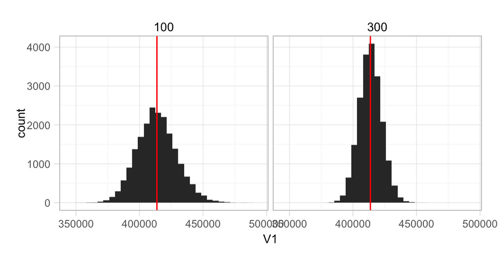

```r
# calculamos el total poblacional
pri_pob <- sum(eleccion_df$APM)

ggplot(tot_estimados, aes(x = V1)) +
  geom_histogram() +
  facet_wrap(~ tamano)  +
  geom_vline(xintercept = pri_pob, color = "red")
```

En ambos casos la línea roja representa el verdadero valor poblacional, vemos que el esquema con $n=300$ es considerablemente más preciso qie el de $n=100$: la distribución está más concentrada cerca del verdadero valor.

Podemos resumir la presición con intervalos de 95% de probabilidad como sigue:

```r
tot_estimados %>%
  group_by(tamano) %>%
  summarise(
    inferior = quantile(V1, probs = 0.025),
    superior = quantile(V1, probs = 0.975),
    inferior_rel = inferior / pri_pob - 1,
    superior_rel = superior / pri_pob - 1
  )
```

```
Source: local data frame [2 x 5]

  tamano inferior superior inferior_rel superior_rel
1    100   384668   445969      -0.0700       0.0781
2    300   396617   431365      -0.0412       0.0428
```

Este último ejemplo no es realista, pues obtuvimos miles de muestras para evaluar la presición de los estimadores. En general, solo tenemos una muestra. La pregunta interesante es: ¿cómo podemos estimar la presición de la estimación con una sola muestra?

Recordando que se trata de un estimador insesgado, podemos usar una medida de dispersión de la distribución de $\hat{t}$ (de la distribución de muestreo) para evaluar su presición. Ya sabemos que en promedio el estimador cae alrededor del  
verdadero valor. Pero, ¿qué tan lejos puede estar? Esta es una pregunta acerca de la dispersión del estimador de H-T. Podríamos calcular distintas medidas de dispersión, pero por el momento nos interesa la varianza. Un poco más adelante justificaremos esta decisión.

La varianza del estimador $\hat{t}$ de H-T está dada por

$Var(\hat{t}) = \sum_{i=1}^N \sum_{j=1}^N \frac{y_i}{\pi_i}\frac{y_j}{\pi_j}(\pi_{ij}-\pi_i\pi_j)$

Nótese que esta es una cantidad poblacional ligada al esquema de muestreo, pues requiereconocer todas las $y_i$ para calcularse. No obstante, usando la misma idea de expansión que usamos para construir el estimador de H-T podemos construir una estimación para esta cantidad. La diferencia es que en este caso expandemos contribuciones de pares de elementos en la muestra:

Esta es una expresión teórica que usaremos más adelante, la iremos particularizando según distintos esquemas de muestreo. Notemos que esta expresión no da mucha luz de cómo podemos hacer más grande o más chica la varianza, es decir, difícilmente da guías de como obtener estimadores precisos.

#### Ejemplo: votos PRI

Consideremos nuevamente el ejemplo de votos totales por el PRI en las casillas del DF. Comenzamos repitiendo la elección de la muestra de tamaño $n=200$.

```r
N <- nrow(eleccion_df)
set.seed(28)
n <- 200
muestra <- sample_n(eleccion_df, size = n)
head(muestra, 3)
```

```
Source: local data frame [3 x 19]

  ID_ENT     NOMBRE_EDO_M DISTRITO_TXT           CAB_MIN           NOM_MIN
1      9 Distrito Federal            1 Gustavo A. Madero Gustavo A. Madero
2      9 Distrito Federal            3      Azcapotzalco      Azcapotzalco
3      9 Distrito Federal           13         Iztacalco         Iztacalco
Variables not shown: TIPO_ELECCION (chr), SECCION (int), CASILLA (chr),
  PAN (int), APM (int), PBT (int), NVA_A (int), ASDC (int),
  NO_VOTOS_CAN_NREG (int), VALIDOS (int), NO_VOTOS_NULOS (int), TOTAL
  (int), LISTA_NOMINAL (int), ESTATUS (lgl)
```

Calculamos el estimador de H-T. Crearemos una nueva columna en la base de datos con el factor de expansión (inverso de la probabilidad de selección para cada elemento de la muestra). En este caso es constante e igual a $N/n$.

```r
muestra$factor <- N/n
```

El estimador de H-T del total es:

```r
sum(muestra$APM * muestra$factor)
```

```
[1] 405529
```

Ahora calculamos la estimación de la varianza de $\hat{t}$. *Nota: usaremos directamente la fórmula de arriba. Esta NO es la forma usual de hacerlo: más adelante veremos una fórmula mucho más conveniente para este caso particular.*

Calculamos dos matrices auxiliares, la primera es:

```r
muestra$y_exp <- muestra$APM * muestra$factor
matriz_1 <- as.matrix(muestra$y_exp) %*% t(as.matrix(muestra$y_exp, ncol = 1))
dim(matriz_1)
```

```
[1] 200 200
```

Para calcular la segunda matriz notamos que en este caso:

$\pi_{ij}=\frac{n}{N}\frac{n-1}{N-1}$

para $i\ne j$.

```r
pi_ij <- n / N * (n - 1) / (N - 1)
pi_ij
```

```
[1] 0.000266
```

```r
factor_ij <- 1 / pi_ij
factor_ij
```

```
[1] 3761
```

y para $i=j$ tenemos

```r
factor_ii <- N / n
factor_ii
```

```
[1] 61.2
```

Ahora extraenos la diagonal de la matriz 1.

```r
mat1_diag <- diag(matriz_1) * (1 - n / N)
```

y fuera de la diagonal tenemos:

```r
mat1_no_diag <- (matriz_1 - diag(diag(matriz_1))) * (1 - ((N - 1) * n) / (N * (n - 1)))
```

Y la estimación de la varianza es:

```r
var_est <- sum(mat1_no_diag) + sum(mat1_diag)
var_est
```

```
[1] 1.27e+08
```

que corresponde a una desviación estándar de

```r
desv_est <- sqrt(var_est)
desv_est
```

```
[1] 11261
```

Y el coeficiente de variación es

```r
round(desv_est / sum(muestra$APM *  muestra$factor), 3)
```

```
[1] 0.028
```

Recordando que este cálculo es sólo un ejemplo, en la próxima sección veremos una fórmula más conveniente.